# Risk Factor Analysis

## Outcome Variable

**Outcome Variable:** stunted

## Predictor Variables

**Intervention Variable:** mbmi

**Adjustment Set:**

- arm
- W_mage
- meducyrs
- feducyrs
- hhwealth_quart
- brthmon
- W_parity
- impfloor
- impsan
- safeh20
- delta_W_mage
- delta_meducyrs
- delta_feducyrs
- delta_hhwealth_quart
- delta_brthmon
- delta_W_parity
- delta_impfloor
- delta_impsan
- delta_safeh20

## Stratifying Variables

The analysis was stratified on these variable(s):

- agecat
- studyid
- country

## Data Summary

| agecat | studyid | country | mbmi | stunted | n_cell | n |
| --- | --- | --- | --- | --- | --- | --- |
| Birth | JiVitA-3 | BANGLADESH | Normal weight | 0 | 9101 | 22355 |
| Birth | JiVitA-3 | BANGLADESH | Normal weight | 1 | 4619 | 22355 |
| Birth | JiVitA-3 | BANGLADESH | Underweight | 0 | 5903 | 22355 |
| Birth | JiVitA-3 | BANGLADESH | Underweight | 1 | 2732 | 22355 |
| Birth | MAL-ED | BANGLADESH | Normal weight | 0 | 159 | 222 |
| Birth | MAL-ED | BANGLADESH | Normal weight | 1 | 35 | 222 |
| Birth | MAL-ED | BANGLADESH | Underweight | 0 | 23 | 222 |
| Birth | MAL-ED | BANGLADESH | Underweight | 1 | 5 | 222 |
| Birth | MAL-ED | BRAZIL | Normal weight | 0 | 52 | 64 |
| Birth | MAL-ED | BRAZIL | Normal weight | 1 | 7 | 64 |
| Birth | MAL-ED | BRAZIL | Underweight | 0 | 3 | 64 |
| Birth | MAL-ED | BRAZIL | Underweight | 1 | 2 | 64 |
| Birth | MAL-ED | INDIA | Normal weight | 0 | 27 | 43 |
| Birth | MAL-ED | INDIA | Normal weight | 1 | 8 | 43 |
| Birth | MAL-ED | INDIA | Underweight | 0 | 7 | 43 |
| Birth | MAL-ED | INDIA | Underweight | 1 | 1 | 43 |
| Birth | MAL-ED | NEPAL | Normal weight | 0 | 25 | 27 |
| Birth | MAL-ED | NEPAL | Normal weight | 1 | 2 | 27 |
| Birth | MAL-ED | NEPAL | Underweight | 0 | 0 | 27 |
| Birth | MAL-ED | NEPAL | Underweight | 1 | 0 | 27 |
| Birth | MAL-ED | PERU | Normal weight | 0 | 197 | 226 |
| Birth | MAL-ED | PERU | Normal weight | 1 | 24 | 226 |
| Birth | MAL-ED | PERU | Underweight | 0 | 3 | 226 |
| Birth | MAL-ED | PERU | Underweight | 1 | 2 | 226 |
| Birth | MAL-ED | SOUTH AFRICA | Normal weight | 0 | 89 | 101 |
| Birth | MAL-ED | SOUTH AFRICA | Normal weight | 1 | 9 | 101 |
| Birth | MAL-ED | SOUTH AFRICA | Underweight | 0 | 3 | 101 |
| Birth | MAL-ED | SOUTH AFRICA | Underweight | 1 | 0 | 101 |
| Birth | MAL-ED | TANZANIA, UNITED REPUBLIC OF | Normal weight | 0 | 96 | 122 |
| Birth | MAL-ED | TANZANIA, UNITED REPUBLIC OF | Normal weight | 1 | 19 | 122 |

[output cut: 150 more lines]

The following strata were considered:

- agecat: 24 months, studyid: JiVitA-3, country: BANGLADESH
- agecat: 24 months, studyid: LCNI-5, country: MALAWI
- agecat: 24 months, studyid: MAL-ED, country: BANGLADESH
- agecat: 24 months, studyid: MAL-ED, country: BRAZIL
- agecat: 24 months, studyid: MAL-ED, country: INDIA
- agecat: 24 months, studyid: MAL-ED, country: NEPAL
- agecat: 24 months, studyid: MAL-ED, country: PERU
- agecat: 24 months, studyid: MAL-ED, country: SOUTH AFRICA
- agecat: 24 months, studyid: MAL-ED, country: TANZANIA, UNITED REPUBLIC OF
- agecat: 24 months, studyid: NIH-Birth, country: BANGLADESH
- agecat: 24 months, studyid: NIH-Crypto, country: BANGLADESH
- agecat: 24 months, studyid: PROBIT, country: BELARUS
- agecat: 24 months, studyid: PROVIDE, country: BANGLADESH
- agecat: 24 months, studyid: TanzaniaChild2, country: TANZANIA, UNITED REPUBLIC OF
- agecat: 24 months, studyid: ZVITAMBO, country: ZIMBABWE
- agecat: 6 months, studyid: JiVitA-3, country: BANGLADESH
- agecat: 6 months, studyid: LCNI-5, country: MALAWI
- agecat: 6 months, studyid: MAL-ED, country: BANGLADESH
- agecat: 6 months, studyid: MAL-ED, country: BRAZIL
- agecat: 6 months, studyid: MAL-ED, country: INDIA
- agecat: 6 months, studyid: MAL-ED, country: NEPAL
- agecat: 6 months, studyid: MAL-ED, country: PERU
- agecat: 6 months, studyid: MAL-ED, country: SOUTH AFRICA
- agecat: 6 months, studyid: MAL-ED, country: TANZANIA, UNITED REPUBLIC OF
- agecat: 6 months, studyid: NIH-Birth, country: BANGLADESH
- agecat: 6 months, studyid: NIH-Crypto, country: BANGLADESH
- agecat: 6 months, studyid: PROBIT, country: BELARUS
- agecat: 6 months, studyid: PROVIDE, country: BANGLADESH
- agecat: 6 months, studyid: SAS-CompFeed, country: INDIA
- agecat: 6 months, studyid: TanzaniaChild2, country: TANZANIA, UNITED REPUBLIC OF
- agecat: 6 months, studyid: ZVITAMBO, country: ZIMBABWE
- agecat: Birth, studyid: JiVitA-3, country: BANGLADESH
- agecat: Birth, studyid: MAL-ED, country: BANGLADESH
- agecat: Birth, studyid: MAL-ED, country: BRAZIL
- agecat: Birth, studyid: MAL-ED, country: INDIA
- agecat: Birth, studyid: MAL-ED, country: NEPAL
- agecat: Birth, studyid: MAL-ED, country: PERU
- agecat: Birth, studyid: MAL-ED, country: SOUTH AFRICA
- agecat: Birth, studyid: MAL-ED, country: TANZANIA, UNITED REPUBLIC OF
- agecat: Birth, studyid: NIH-Birth, country: BANGLADESH
- agecat: Birth, studyid: NIH-Crypto, country: BANGLADESH
- agecat: Birth, studyid: PROBIT, country: BELARUS
- agecat: Birth, studyid: PROVIDE, country: BANGLADESH
- agecat: Birth, studyid: SAS-CompFeed, country: INDIA
- agecat: Birth, studyid: ZVITAMBO, country: ZIMBABWE

### Dropped Strata

Some strata were dropped due to rare outcomes:

- agecat: Birth, studyid: MAL-ED, country: BRAZIL
- agecat: Birth, studyid: MAL-ED, country: INDIA
- agecat: Birth, studyid: MAL-ED, country: NEPAL
- agecat: Birth, studyid: MAL-ED, country: PERU
- agecat: Birth, studyid: MAL-ED, country: SOUTH AFRICA
- agecat: Birth, studyid: MAL-ED, country: TANZANIA, UNITED REPUBLIC OF
- agecat: Birth, studyid: PROBIT, country: BELARUS
- agecat: 6 months, studyid: MAL-ED, country: BRAZIL
- agecat: 6 months, studyid: MAL-ED, country: NEPAL
- agecat: 6 months, studyid: MAL-ED, country: PERU
- agecat: 6 months, studyid: MAL-ED, country: SOUTH AFRICA
- agecat: 6 months, studyid: MAL-ED, country: TANZANIA, UNITED REPUBLIC OF
- agecat: 6 months, studyid: TanzaniaChild2, country: TANZANIA, UNITED REPUBLIC OF
- agecat: 24 months, studyid: MAL-ED, country: BRAZIL
- agecat: 24 months, studyid: MAL-ED, country: NEPAL
- agecat: 24 months, studyid: MAL-ED, country: PERU
- agecat: 24 months, studyid: MAL-ED, country: SOUTH AFRICA
- agecat: 24 months, studyid: MAL-ED, country: TANZANIA, UNITED REPUBLIC OF
- agecat: 24 months, studyid: TanzaniaChild2, country: TANZANIA, UNITED REPUBLIC OF

## Methods Detail

We’re interested in the causal parameters $E[Y_a]$ for all values of $a \in \mathcal{A}$. These parameters represent the mean outcome if, possibly contrary to fact, we intervened to set all units to have $A=a$. Under the randomization and positivity assumptions, these are identified by the statistical parameters $\psi_a=E_W[E_{Y|A,W}(Y|A=a,W)]$. In addition, we’re interested in the mean of $Y$, $E[Y]$ under no intervention (the observed mean). We will estimate these parameters by using SuperLearner to fit the relevant likelihood factors – $E_{Y|A,W}(Y|A=a,W)$ and $p(A=a|W)$, and then updating our likelihood fit using a joint TMLE.

For unadjusted analyses ($W=\{\}$), initial likelihoods were estimated using Lrnr_glm to estimate the simple $E(Y|A)$ and Lrnr_mean to estimate $p(A)$. For adjusted analyses, a small library containing Lrnr_glmnet, Lrnr_xgboost, and Lrnr_mean was used.

Having estimated these parameters, we will then use the delta method to estimate relative risks and attributable risks relative to a prespecified baseline level of $A$.

# Results Detail

## Results Plots

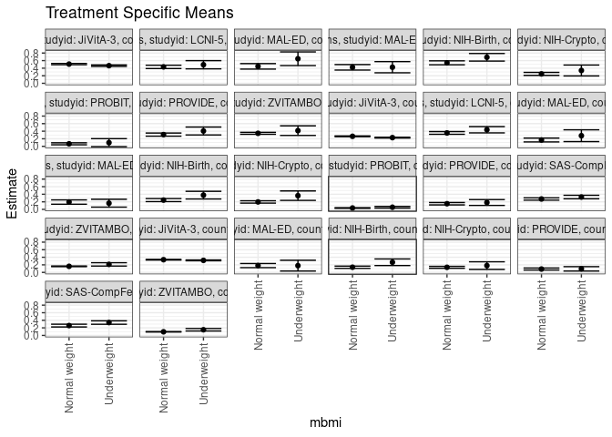

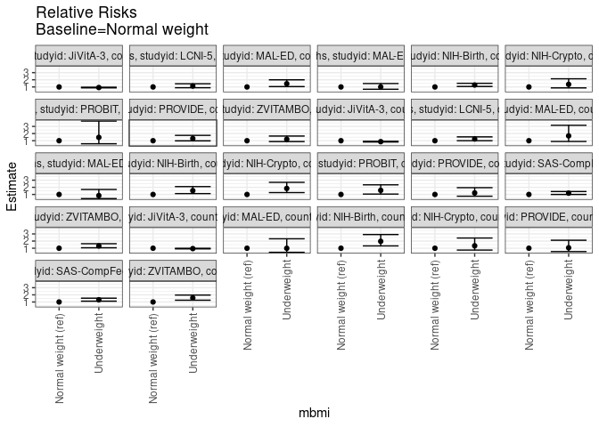

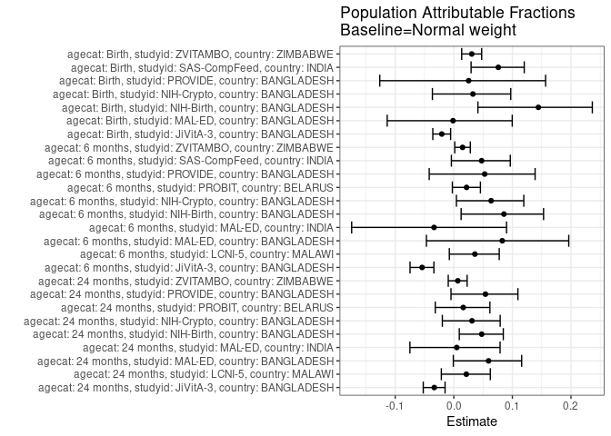

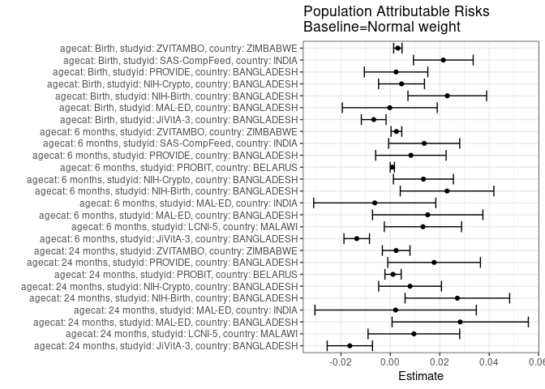

## Results Table

### Parameter: TSM

| agecat | studyid | country | intervention_level | baseline_level | estimate | ci_lower | ci_upper |
| --- | --- | --- | --- | --- | --- | --- | --- |
| Birth | JiVitA-3 | BANGLADESH | Normal weight | NA | 0.3355732 | 0.3265727 | 0.3445736 |
| Birth | JiVitA-3 | BANGLADESH | Underweight | NA | 0.3180041 | 0.3071660 | 0.3288422 |
| Birth | MAL-ED | BANGLADESH | Normal weight | NA | 0.1804124 | 0.1261800 | 0.2346447 |
| Birth | MAL-ED | BANGLADESH | Underweight | NA | 0.1785714 | 0.0363908 | 0.3207520 |
| Birth | NIH-Birth | BANGLADESH | Normal weight | NA | 0.1365065 | 0.1065399 | 0.1664730 |
| Birth | NIH-Birth | BANGLADESH | Underweight | NA | 0.2679258 | 0.1801364 | 0.3557153 |
| Birth | NIH-Crypto | BANGLADESH | Normal weight | NA | 0.1340229 | 0.1079110 | 0.1601347 |
| Birth | NIH-Crypto | BANGLADESH | Underweight | NA | 0.1795649 | 0.0787212 | 0.2804086 |
| Birth | PROVIDE | BANGLADESH | Normal weight | NA | 0.0885989 | 0.0613684 | 0.1158294 |
| Birth | PROVIDE | BANGLADESH | Underweight | NA | 0.0940069 | 0.0363218 | 0.1516921 |
| Birth | SAS-CompFeed | INDIA | Normal weight | NA | 0.2605090 | 0.2238654 | 0.2971525 |
| Birth | SAS-CompFeed | INDIA | Underweight | NA | 0.3404200 | 0.2950130 | 0.3858270 |
| Birth | ZVITAMBO | ZIMBABWE | Normal weight | NA | 0.0959103 | 0.0898813 | 0.1019393 |
| Birth | ZVITAMBO | ZIMBABWE | Underweight | NA | 0.1502951 | 0.1173848 | 0.1832054 |
| 6 months | JiVitA-3 | BANGLADESH | Normal weight | NA | 0.2651637 | 0.2549735 | 0.2753540 |
| 6 months | JiVitA-3 | BANGLADESH | Underweight | NA | 0.2301381 | 0.2193801 | 0.2408962 |
| 6 months | LCNI-5 | MALAWI | Normal weight | NA | 0.3540375 | 0.3182252 | 0.3898498 |
| 6 months | LCNI-5 | MALAWI | Underweight | NA | 0.4385060 | 0.3556777 | 0.5213342 |
| 6 months | MAL-ED | BANGLADESH | Normal weight | NA | 0.1674641 | 0.1167370 | 0.2181912 |
| 6 months | MAL-ED | BANGLADESH | Underweight | NA | 0.2812500 | 0.1251470 | 0.4373530 |
| 6 months | MAL-ED | INDIA | Normal weight | NA | 0.1935484 | 0.1366498 | 0.2504470 |
| 6 months | MAL-ED | INDIA | Underweight | NA | 0.1632653 | 0.0595562 | 0.2669744 |
| 6 months | NIH-Birth | BANGLADESH | Normal weight | NA | 0.2452126 | 0.2051521 | 0.2852731 |
| 6 months | NIH-Birth | BANGLADESH | Underweight | NA | 0.3760115 | 0.2747425 | 0.4772805 |
| 6 months | NIH-Crypto | BANGLADESH | Normal weight | NA | 0.1964167 | 0.1654956 | 0.2273379 |
| 6 months | NIH-Crypto | BANGLADESH | Underweight | NA | 0.3623086 | 0.2376067 | 0.4870106 |
| 6 months | PROBIT | BELARUS | Normal weight | NA | 0.0360496 | 0.0267959 | 0.0453032 |
| 6 months | PROBIT | BELARUS | Underweight | NA | 0.0567801 | 0.0347340 | 0.0788262 |
| 6 months | PROVIDE | BANGLADESH | Normal weight | NA | 0.1492402 | 0.1178391 | 0.1806413 |
| 6 months | PROVIDE | BANGLADESH | Underweight | NA | 0.1811461 | 0.1042295 | 0.2580626 |
| 6 months | SAS-CompFeed | INDIA | Normal weight | NA | 0.2745848 | 0.2444384 | 0.3047313 |
| 6 months | SAS-CompFeed | INDIA | Underweight | NA | 0.3261763 | 0.2798757 | 0.3724769 |
| 6 months | ZVITAMBO | ZIMBABWE | Normal weight | NA | 0.1606699 | 0.1520586 | 0.1692813 |
| 6 months | ZVITAMBO | ZIMBABWE | Underweight | NA | 0.2115096 | 0.1674434 | 0.2555759 |
| 24 months | JiVitA-3 | BANGLADESH | Normal weight | NA | 0.5078545 | 0.4913884 | 0.5243206 |
| 24 months | JiVitA-3 | BANGLADESH | Underweight | NA | 0.4661063 | 0.4470756 | 0.4851370 |
| 24 months | LCNI-5 | MALAWI | Normal weight | NA | 0.4341604 | 0.3897052 | 0.4786155 |
| 24 months | LCNI-5 | MALAWI | Underweight | NA | 0.4909262 | 0.3823757 | 0.5994766 |
| 24 months | MAL-ED | BANGLADESH | Normal weight | NA | 0.4481514 | 0.3758151 | 0.5204878 |
| 24 months | MAL-ED | BANGLADESH | Underweight | NA | 0.6489220 | 0.4684510 | 0.8293929 |
| 24 months | MAL-ED | INDIA | Normal weight | NA | 0.4226427 | 0.3501609 | 0.4951244 |
| 24 months | MAL-ED | INDIA | Underweight | NA | 0.4248357 | 0.2773134 | 0.5723580 |
| 24 months | NIH-Birth | BANGLADESH | Normal weight | NA | 0.5416583 | 0.4894720 | 0.5938446 |
| 24 months | NIH-Birth | BANGLADESH | Underweight | NA | 0.6878880 | 0.5874115 | 0.7883645 |
| 24 months | NIH-Crypto | BANGLADESH | Normal weight | NA | 0.2488327 | 0.2097608 | 0.2879046 |
| 24 months | NIH-Crypto | BANGLADESH | Underweight | NA | 0.3391996 | 0.1952583 | 0.4831409 |
| 24 months | PROBIT | BELARUS | Normal weight | NA | 0.0668217 | 0.0406250 | 0.0930183 |
| 24 months | PROBIT | BELARUS | Underweight | NA | 0.0979126 | -0.0071090 | 0.2029342 |
| 24 months | PROVIDE | BANGLADESH | Normal weight | NA | 0.3098553 | 0.2684715 | 0.3512391 |
| 24 months | PROVIDE | BANGLADESH | Underweight | NA | 0.4055746 | 0.3007843 | 0.5103649 |
| 24 months | ZVITAMBO | ZIMBABWE | Normal weight | NA | 0.3443359 | 0.3186080 | 0.3700639 |
| 24 months | ZVITAMBO | ZIMBABWE | Underweight | NA | 0.4152465 | 0.2879131 | 0.5425799 |

### Parameter: E(Y)

| agecat | studyid | country | intervention_level | baseline_level | estimate | ci_lower | ci_upper |
| --- | --- | --- | --- | --- | --- | --- | --- |
| Birth | JiVitA-3 | BANGLADESH | NA | NA | 0.3288302 | 0.3214550 | 0.3362055 |
| Birth | MAL-ED | BANGLADESH | NA | NA | 0.1801802 | 0.1295086 | 0.2308518 |
| Birth | NIH-Birth | BANGLADESH | NA | NA | 0.1595395 | 0.1304091 | 0.1886699 |
| Birth | NIH-Crypto | BANGLADESH | NA | NA | 0.1385460 | 0.1134505 | 0.1636414 |
| Birth | PROVIDE | BANGLADESH | NA | NA | 0.0909091 | 0.0661046 | 0.1157136 |
| Birth | SAS-CompFeed | INDIA | NA | NA | 0.2819383 | 0.2495848 | 0.3142918 |
| Birth | ZVITAMBO | ZIMBABWE | NA | NA | 0.0989454 | 0.0929945 | 0.1048964 |
| 6 months | JiVitA-3 | BANGLADESH | NA | NA | 0.2515513 | 0.2434364 | 0.2596662 |
| 6 months | LCNI-5 | MALAWI | NA | NA | 0.3672249 | 0.3345288 | 0.3999210 |
| 6 months | MAL-ED | BANGLADESH | NA | NA | 0.1825726 | 0.1336978 | 0.2314474 |
| 6 months | MAL-ED | INDIA | NA | NA | 0.1872340 | 0.1372518 | 0.2372162 |
| 6 months | NIH-Birth | BANGLADESH | NA | NA | 0.2681564 | 0.2306532 | 0.3056597 |
| 6 months | NIH-Crypto | BANGLADESH | NA | NA | 0.2097902 | 0.1799252 | 0.2396552 |
| 6 months | PROBIT | BELARUS | NA | NA | 0.0368522 | 0.0276927 | 0.0460117 |
| 6 months | PROVIDE | BANGLADESH | NA | NA | 0.1575456 | 0.1284434 | 0.1866478 |
| 6 months | SAS-CompFeed | INDIA | NA | NA | 0.2882736 | 0.2624662 | 0.3140810 |
| 6 months | ZVITAMBO | ZIMBABWE | NA | NA | 0.1631186 | 0.1546857 | 0.1715516 |
| 24 months | JiVitA-3 | BANGLADESH | NA | NA | 0.4914525 | 0.4783104 | 0.5045946 |
| 24 months | LCNI-5 | MALAWI | NA | NA | 0.4436742 | 0.4031015 | 0.4842468 |
| 24 months | MAL-ED | BANGLADESH | NA | NA | 0.4764151 | 0.4090254 | 0.5438047 |
| 24 months | MAL-ED | INDIA | NA | NA | 0.4247788 | 0.3601902 | 0.4893673 |
| 24 months | NIH-Birth | BANGLADESH | NA | NA | 0.5687646 | 0.5218455 | 0.6156837 |
| 24 months | NIH-Crypto | BANGLADESH | NA | NA | 0.2568093 | 0.2190047 | 0.2946140 |
| 24 months | PROBIT | BELARUS | NA | NA | 0.0679151 | 0.0407521 | 0.0950781 |
| 24 months | PROVIDE | BANGLADESH | NA | NA | 0.3275563 | 0.2892291 | 0.3658836 |
| 24 months | ZVITAMBO | ZIMBABWE | NA | NA | 0.3466861 | 0.3215035 | 0.3718687 |

### Parameter: RR

| agecat | studyid | country | intervention_level | baseline_level | estimate | ci_lower | ci_upper |
| --- | --- | --- | --- | --- | --- | --- | --- |
| Birth | JiVitA-3 | BANGLADESH | Normal weight | Normal weight | 1.0000000 | 1.0000000 | 1.0000000 |
| Birth | JiVitA-3 | BANGLADESH | Underweight | Normal weight | 0.9476447 | 0.9104621 | 0.9863457 |
| Birth | MAL-ED | BANGLADESH | Normal weight | Normal weight | 1.0000000 | 1.0000000 | 1.0000000 |
| Birth | MAL-ED | BANGLADESH | Underweight | Normal weight | 0.9897959 | 0.4226026 | 2.3182439 |
| Birth | NIH-Birth | BANGLADESH | Normal weight | Normal weight | 1.0000000 | 1.0000000 | 1.0000000 |
| Birth | NIH-Birth | BANGLADESH | Underweight | Normal weight | 1.9627339 | 1.3226502 | 2.9125797 |
| Birth | NIH-Crypto | BANGLADESH | Normal weight | Normal weight | 1.0000000 | 1.0000000 | 1.0000000 |
| Birth | NIH-Crypto | BANGLADESH | Underweight | Normal weight | 1.3398077 | 0.7394139 | 2.4277129 |
| Birth | PROVIDE | BANGLADESH | Normal weight | Normal weight | 1.0000000 | 1.0000000 | 1.0000000 |
| Birth | PROVIDE | BANGLADESH | Underweight | Normal weight | 1.0610397 | 0.5322925 | 2.1150124 |
| Birth | SAS-CompFeed | INDIA | Normal weight | Normal weight | 1.0000000 | 1.0000000 | 1.0000000 |
| Birth | SAS-CompFeed | INDIA | Underweight | Normal weight | 1.3067497 | 1.1165758 | 1.5293137 |
| Birth | ZVITAMBO | ZIMBABWE | Normal weight | Normal weight | 1.0000000 | 1.0000000 | 1.0000000 |
| Birth | ZVITAMBO | ZIMBABWE | Underweight | Normal weight | 1.5670381 | 1.2478470 | 1.9678763 |
| 6 months | JiVitA-3 | BANGLADESH | Normal weight | Normal weight | 1.0000000 | 1.0000000 | 1.0000000 |
| 6 months | JiVitA-3 | BANGLADESH | Underweight | Normal weight | 0.8679095 | 0.8216435 | 0.9167807 |
| 6 months | LCNI-5 | MALAWI | Normal weight | Normal weight | 1.0000000 | 1.0000000 | 1.0000000 |
| 6 months | LCNI-5 | MALAWI | Underweight | Normal weight | 1.2385862 | 0.9996783 | 1.5345894 |
| 6 months | MAL-ED | BANGLADESH | Normal weight | Normal weight | 1.0000000 | 1.0000000 | 1.0000000 |
| 6 months | MAL-ED | BANGLADESH | Underweight | Normal weight | 1.6794643 | 0.8924037 | 3.1606777 |
| 6 months | MAL-ED | INDIA | Normal weight | Normal weight | 1.0000000 | 1.0000000 | 1.0000000 |
| 6 months | MAL-ED | INDIA | Underweight | Normal weight | 0.8435374 | 0.4189110 | 1.6985838 |
| 6 months | NIH-Birth | BANGLADESH | Normal weight | Normal weight | 1.0000000 | 1.0000000 | 1.0000000 |
| 6 months | NIH-Birth | BANGLADESH | Underweight | Normal weight | 1.5334104 | 1.1191055 | 2.1010953 |
| 6 months | NIH-Crypto | BANGLADESH | Normal weight | Normal weight | 1.0000000 | 1.0000000 | 1.0000000 |
| 6 months | NIH-Crypto | BANGLADESH | Underweight | Normal weight | 1.8445916 | 1.2624977 | 2.6950690 |
| 6 months | PROBIT | BELARUS | Normal weight | Normal weight | 1.0000000 | 1.0000000 | 1.0000000 |
| 6 months | PROBIT | BELARUS | Underweight | Normal weight | 1.5750556 | 1.0560043 | 2.3492329 |
| 6 months | PROVIDE | BANGLADESH | Normal weight | Normal weight | 1.0000000 | 1.0000000 | 1.0000000 |
| 6 months | PROVIDE | BANGLADESH | Underweight | Normal weight | 1.2137889 | 0.7560855 | 1.9485673 |
| 6 months | SAS-CompFeed | INDIA | Normal weight | Normal weight | 1.0000000 | 1.0000000 | 1.0000000 |
| 6 months | SAS-CompFeed | INDIA | Underweight | Normal weight | 1.1878890 | 0.9987112 | 1.4129011 |
| 6 months | ZVITAMBO | ZIMBABWE | Normal weight | Normal weight | 1.0000000 | 1.0000000 | 1.0000000 |
| 6 months | ZVITAMBO | ZIMBABWE | Underweight | Normal weight | 1.3164231 | 1.0616535 | 1.6323308 |
| 24 months | JiVitA-3 | BANGLADESH | Normal weight | Normal weight | 1.0000000 | 1.0000000 | 1.0000000 |
| 24 months | JiVitA-3 | BANGLADESH | Underweight | Normal weight | 0.9177949 | 0.8737158 | 0.9640978 |
| 24 months | LCNI-5 | MALAWI | Normal weight | Normal weight | 1.0000000 | 1.0000000 | 1.0000000 |
| 24 months | LCNI-5 | MALAWI | Underweight | Normal weight | 1.1307485 | 0.8862013 | 1.4427784 |
| 24 months | MAL-ED | BANGLADESH | Normal weight | Normal weight | 1.0000000 | 1.0000000 | 1.0000000 |
| 24 months | MAL-ED | BANGLADESH | Underweight | Normal weight | 1.4479971 | 1.0494148 | 1.9979665 |
| 24 months | MAL-ED | INDIA | Normal weight | Normal weight | 1.0000000 | 1.0000000 | 1.0000000 |
| 24 months | MAL-ED | INDIA | Underweight | Normal weight | 1.0051890 | 0.6826122 | 1.4802033 |
| 24 months | NIH-Birth | BANGLADESH | Normal weight | Normal weight | 1.0000000 | 1.0000000 | 1.0000000 |
| 24 months | NIH-Birth | BANGLADESH | Underweight | Normal weight | 1.2699666 | 1.0678414 | 1.5103509 |
| 24 months | NIH-Crypto | BANGLADESH | Normal weight | Normal weight | 1.0000000 | 1.0000000 | 1.0000000 |
| 24 months | NIH-Crypto | BANGLADESH | Underweight | Normal weight | 1.3631632 | 0.8680348 | 2.1407135 |
| 24 months | PROBIT | BELARUS | Normal weight | Normal weight | 1.0000000 | 1.0000000 | 1.0000000 |
| 24 months | PROBIT | BELARUS | Underweight | Normal weight | 1.4652824 | 0.5725223 | 3.7501639 |
| 24 months | PROVIDE | BANGLADESH | Normal weight | Normal weight | 1.0000000 | 1.0000000 | 1.0000000 |
| 24 months | PROVIDE | BANGLADESH | Underweight | Normal weight | 1.3089162 | 0.9790862 | 1.7498578 |
| 24 months | ZVITAMBO | ZIMBABWE | Normal weight | Normal weight | 1.0000000 | 1.0000000 | 1.0000000 |
| 24 months | ZVITAMBO | ZIMBABWE | Underweight | Normal weight | 1.2059343 | 0.8798134 | 1.6529386 |

### Parameter: PAR

| agecat | studyid | country | intervention_level | baseline_level | estimate | ci_lower | ci_upper |
| --- | --- | --- | --- | --- | --- | --- | --- |
| Birth | JiVitA-3 | BANGLADESH | Normal weight | NA | -0.0067429 | -0.0117481 | -0.0017378 |
| Birth | MAL-ED | BANGLADESH | Normal weight | NA | -0.0002322 | -0.0194253 | 0.0189609 |
| Birth | NIH-Birth | BANGLADESH | Normal weight | NA | 0.0230330 | 0.0071167 | 0.0389493 |
| Birth | NIH-Crypto | BANGLADESH | Normal weight | NA | 0.0045231 | -0.0047586 | 0.0138047 |
| Birth | PROVIDE | BANGLADESH | Normal weight | NA | 0.0023102 | -0.0105350 | 0.0151554 |
| Birth | SAS-CompFeed | INDIA | Normal weight | NA | 0.0214294 | 0.0093450 | 0.0335138 |
| Birth | ZVITAMBO | ZIMBABWE | Normal weight | NA | 0.0030351 | 0.0013405 | 0.0047298 |
| 6 months | JiVitA-3 | BANGLADESH | Normal weight | NA | -0.0136124 | -0.0187764 | -0.0084485 |
| 6 months | LCNI-5 | MALAWI | Normal weight | NA | 0.0131874 | -0.0024439 | 0.0288186 |
| 6 months | MAL-ED | BANGLADESH | Normal weight | NA | 0.0151085 | -0.0072265 | 0.0374435 |
| 6 months | MAL-ED | INDIA | Normal weight | NA | -0.0063143 | -0.0310298 | 0.0184011 |
| 6 months | NIH-Birth | BANGLADESH | Normal weight | NA | 0.0229439 | 0.0040047 | 0.0418830 |
| 6 months | NIH-Crypto | BANGLADESH | Normal weight | NA | 0.0133735 | 0.0012458 | 0.0255012 |
| 6 months | PROBIT | BELARUS | Normal weight | NA | 0.0008026 | -0.0000438 | 0.0016490 |
| 6 months | PROVIDE | BANGLADESH | Normal weight | NA | 0.0083054 | -0.0059467 | 0.0225575 |
| 6 months | SAS-CompFeed | INDIA | Normal weight | NA | 0.0136888 | -0.0006876 | 0.0280652 |
| 6 months | ZVITAMBO | ZIMBABWE | Normal weight | NA | 0.0024487 | 0.0002824 | 0.0046150 |
| 24 months | JiVitA-3 | BANGLADESH | Normal weight | NA | -0.0164020 | -0.0255676 | -0.0072365 |
| 24 months | LCNI-5 | MALAWI | Normal weight | NA | 0.0095138 | -0.0090234 | 0.0280510 |
| 24 months | MAL-ED | BANGLADESH | Normal weight | NA | 0.0282637 | 0.0007007 | 0.0558267 |
| 24 months | MAL-ED | INDIA | Normal weight | NA | 0.0021361 | -0.0305177 | 0.0347899 |
| 24 months | NIH-Birth | BANGLADESH | Normal weight | NA | 0.0271062 | 0.0059486 | 0.0482639 |
| 24 months | NIH-Crypto | BANGLADESH | Normal weight | NA | 0.0079766 | -0.0047164 | 0.0206697 |
| 24 months | PROBIT | BELARUS | Normal weight | NA | 0.0010935 | -0.0021974 | 0.0043843 |
| 24 months | PROVIDE | BANGLADESH | Normal weight | NA | 0.0177011 | -0.0010381 | 0.0364402 |
| 24 months | ZVITAMBO | ZIMBABWE | Normal weight | NA | 0.0023502 | -0.0032345 | 0.0079348 |

### Parameter: PAF

| agecat | studyid | country | intervention_level | baseline_level | estimate | ci_lower | ci_upper |
| --- | --- | --- | --- | --- | --- | --- | --- |
| Birth | JiVitA-3 | BANGLADESH | Normal weight | NA | -0.0205058 | -0.0358381 | -0.0054005 |
| Birth | MAL-ED | BANGLADESH | Normal weight | NA | -0.0012887 | -0.1136825 | 0.0997623 |
| Birth | NIH-Birth | BANGLADESH | Normal weight | NA | 0.1443719 | 0.0411866 | 0.2364527 |
| Birth | NIH-Crypto | BANGLADESH | Normal weight | NA | 0.0326467 | -0.0365365 | 0.0972123 |
| Birth | PROVIDE | BANGLADESH | Normal weight | NA | 0.0254122 | -0.1263498 | 0.1567261 |
| Birth | SAS-CompFeed | INDIA | Normal weight | NA | 0.0760073 | 0.0295261 | 0.1202622 |
| Birth | ZVITAMBO | ZIMBABWE | Normal weight | NA | 0.0306747 | 0.0134746 | 0.0475749 |
| 6 months | JiVitA-3 | BANGLADESH | Normal weight | NA | -0.0541139 | -0.0746781 | -0.0339433 |
| 6 months | LCNI-5 | MALAWI | Normal weight | NA | 0.0359109 | -0.0076333 | 0.0775734 |
| 6 months | MAL-ED | BANGLADESH | Normal weight | NA | 0.0827534 | -0.0467563 | 0.1962395 |
| 6 months | MAL-ED | INDIA | Normal weight | NA | -0.0337243 | -0.1743434 | 0.0900566 |
| 6 months | NIH-Birth | BANGLADESH | Normal weight | NA | 0.0855615 | 0.0125000 | 0.1532174 |
| 6 months | NIH-Crypto | BANGLADESH | Normal weight | NA | 0.0637470 | 0.0044640 | 0.1194998 |
| 6 months | PROBIT | BELARUS | Normal weight | NA | 0.0217798 | -0.0024553 | 0.0454290 |
| 6 months | PROVIDE | BANGLADESH | Normal weight | NA | 0.0527176 | -0.0419555 | 0.1387886 |
| 6 months | SAS-CompFeed | INDIA | Normal weight | NA | 0.0474854 | -0.0041212 | 0.0964397 |
| 6 months | ZVITAMBO | ZIMBABWE | Normal weight | NA | 0.0150118 | 0.0016538 | 0.0281911 |
| 24 months | JiVitA-3 | BANGLADESH | Normal weight | NA | -0.0333746 | -0.0521611 | -0.0149235 |
| 24 months | LCNI-5 | MALAWI | Normal weight | NA | 0.0214433 | -0.0212723 | 0.0623722 |
| 24 months | MAL-ED | BANGLADESH | Normal weight | NA | 0.0593257 | -0.0008263 | 0.1158624 |
| 24 months | MAL-ED | INDIA | Normal weight | NA | 0.0050287 | -0.0748985 | 0.0790128 |
| 24 months | NIH-Birth | BANGLADESH | Normal weight | NA | 0.0476581 | 0.0093552 | 0.0844800 |
| 24 months | NIH-Crypto | BANGLADESH | Normal weight | NA | 0.0310605 | -0.0195510 | 0.0791596 |
| 24 months | PROBIT | BELARUS | Normal weight | NA | 0.0161003 | -0.0316221 | 0.0616151 |
| 24 months | PROVIDE | BANGLADESH | Normal weight | NA | 0.0540397 | -0.0048029 | 0.1094365 |
| 24 months | ZVITAMBO | ZIMBABWE | Normal weight | NA | 0.0067790 | -0.0094626 | 0.0227592 |